# Risk Factor Analysis

## Outcome Variable

**Outcome Variable:** sstunted

## Predictor Variables

**Intervention Variable:** enstunt

**Adjustment Set:**

- arm
- sex
- W_mage
- meducyrs
- feducyrs
- vagbrth
- single
- brthmon
- W_parity
- impsan
- delta_W_mage
- delta_meducyrs
- delta_feducyrs
- delta_vagbrth
- delta_single
- delta_brthmon
- delta_W_parity
- delta_impsan

## Stratifying Variables

The analysis was stratified on these variable(s):

- agecat
- studyid
- country

## Data Summary

| agecat | studyid | country | enstunt | sstunted | n_cell | n |
| --- | --- | --- | --- | --- | --- | --- |
| Birth | CMC-V-BCS-2002 | INDIA | 0 | 0 | 75 | 92 |
| Birth | CMC-V-BCS-2002 | INDIA | 0 | 1 | 0 | 92 |
| Birth | CMC-V-BCS-2002 | INDIA | 1 | 0 | 13 | 92 |
| Birth | CMC-V-BCS-2002 | INDIA | 1 | 1 | 4 | 92 |
| Birth | CMIN | BANGLADESH | 0 | 0 | 17 | 26 |
| Birth | CMIN | BANGLADESH | 0 | 1 | 0 | 26 |
| Birth | CMIN | BANGLADESH | 1 | 0 | 3 | 26 |
| Birth | CMIN | BANGLADESH | 1 | 1 | 6 | 26 |
| Birth | COHORTS | GUATEMALA | 0 | 0 | 802 | 852 |
| Birth | COHORTS | GUATEMALA | 0 | 1 | 0 | 852 |
| Birth | COHORTS | GUATEMALA | 1 | 0 | 39 | 852 |
| Birth | COHORTS | GUATEMALA | 1 | 1 | 11 | 852 |
| Birth | COHORTS | INDIA | 0 | 0 | 5848 | 6640 |
| Birth | COHORTS | INDIA | 0 | 1 | 0 | 6640 |
| Birth | COHORTS | INDIA | 1 | 0 | 586 | 6640 |
| Birth | COHORTS | INDIA | 1 | 1 | 206 | 6640 |
| Birth | COHORTS | PHILIPPINES | 0 | 0 | 2863 | 3050 |
| Birth | COHORTS | PHILIPPINES | 0 | 1 | 0 | 3050 |
| Birth | COHORTS | PHILIPPINES | 1 | 0 | 141 | 3050 |
| Birth | COHORTS | PHILIPPINES | 1 | 1 | 46 | 3050 |
| Birth | CONTENT | PERU | 0 | 0 | 2 | 2 |
| Birth | CONTENT | PERU | 0 | 1 | 0 | 2 |
| Birth | CONTENT | PERU | 1 | 0 | 0 | 2 |
| Birth | CONTENT | PERU | 1 | 1 | 0 | 2 |
| Birth | EE | PAKISTAN | 0 | 0 | 140 | 240 |
| Birth | EE | PAKISTAN | 0 | 1 | 0 | 240 |
| Birth | EE | PAKISTAN | 1 | 0 | 52 | 240 |
| Birth | EE | PAKISTAN | 1 | 1 | 48 | 240 |
| Birth | GMS-Nepal | NEPAL | 0 | 0 | 574 | 696 |
| Birth | GMS-Nepal | NEPAL | 0 | 1 | 0 | 696 |

[output cut: 298 more lines]

The following strata were considered:

- agecat: 24 months, studyid: CMC-V-BCS-2002, country: INDIA
- agecat: 24 months, studyid: CMIN, country: BANGLADESH
- agecat: 24 months, studyid: COHORTS, country: GUATEMALA
- agecat: 24 months, studyid: COHORTS, country: INDIA
- agecat: 24 months, studyid: COHORTS, country: PHILIPPINES
- agecat: 24 months, studyid: CONTENT, country: PERU
- agecat: 24 months, studyid: EE, country: PAKISTAN
- agecat: 24 months, studyid: GMS-Nepal, country: NEPAL
- agecat: 24 months, studyid: IRC, country: INDIA
- agecat: 24 months, studyid: JiVitA-3, country: BANGLADESH
- agecat: 24 months, studyid: JiVitA-4, country: BANGLADESH
- agecat: 24 months, studyid: Keneba, country: GAMBIA
- agecat: 24 months, studyid: LCNI-5, country: MALAWI
- agecat: 24 months, studyid: MAL-ED, country: BANGLADESH
- agecat: 24 months, studyid: MAL-ED, country: BRAZIL
- agecat: 24 months, studyid: MAL-ED, country: INDIA
- agecat: 24 months, studyid: MAL-ED, country: NEPAL
- agecat: 24 months, studyid: MAL-ED, country: PERU
- agecat: 24 months, studyid: MAL-ED, country: SOUTH AFRICA
- agecat: 24 months, studyid: MAL-ED, country: TANZANIA, UNITED REPUBLIC OF
- agecat: 24 months, studyid: NIH-Birth, country: BANGLADESH
- agecat: 24 months, studyid: NIH-Crypto, country: BANGLADESH
- agecat: 24 months, studyid: PROBIT, country: BELARUS
- agecat: 24 months, studyid: PROVIDE, country: BANGLADESH
- agecat: 24 months, studyid: TanzaniaChild2, country: TANZANIA, UNITED REPUBLIC OF
- agecat: 24 months, studyid: ZVITAMBO, country: ZIMBABWE
- agecat: 6 months, studyid: CMC-V-BCS-2002, country: INDIA
- agecat: 6 months, studyid: CMIN, country: BANGLADESH
- agecat: 6 months, studyid: COHORTS, country: GUATEMALA
- agecat: 6 months, studyid: COHORTS, country: INDIA
- agecat: 6 months, studyid: COHORTS, country: PHILIPPINES
- agecat: 6 months, studyid: CONTENT, country: PERU
- agecat: 6 months, studyid: EE, country: PAKISTAN
- agecat: 6 months, studyid: GMS-Nepal, country: NEPAL
- agecat: 6 months, studyid: Guatemala BSC, country: GUATEMALA
- agecat: 6 months, studyid: IRC, country: INDIA
- agecat: 6 months, studyid: JiVitA-3, country: BANGLADESH
- agecat: 6 months, studyid: JiVitA-4, country: BANGLADESH
- agecat: 6 months, studyid: Keneba, country: GAMBIA
- agecat: 6 months, studyid: LCNI-5, country: MALAWI
- agecat: 6 months, studyid: MAL-ED, country: BANGLADESH
- agecat: 6 months, studyid: MAL-ED, country: BRAZIL
- agecat: 6 months, studyid: MAL-ED, country: INDIA
- agecat: 6 months, studyid: MAL-ED, country: NEPAL
- agecat: 6 months, studyid: MAL-ED, country: PERU
- agecat: 6 months, studyid: MAL-ED, country: SOUTH AFRICA
- agecat: 6 months, studyid: MAL-ED, country: TANZANIA, UNITED REPUBLIC OF
- agecat: 6 months, studyid: NIH-Birth, country: BANGLADESH
- agecat: 6 months, studyid: NIH-Crypto, country: BANGLADESH
- agecat: 6 months, studyid: PROBIT, country: BELARUS
- agecat: 6 months, studyid: PROVIDE, country: BANGLADESH
- agecat: 6 months, studyid: ResPak, country: PAKISTAN
- agecat: 6 months, studyid: SAS-CompFeed, country: INDIA
- agecat: 6 months, studyid: SAS-FoodSuppl, country: INDIA
- agecat: 6 months, studyid: TanzaniaChild2, country: TANZANIA, UNITED REPUBLIC OF
- agecat: 6 months, studyid: ZVITAMBO, country: ZIMBABWE
- agecat: Birth, studyid: CMC-V-BCS-2002, country: INDIA
- agecat: Birth, studyid: CMIN, country: BANGLADESH
- agecat: Birth, studyid: COHORTS, country: GUATEMALA
- agecat: Birth, studyid: COHORTS, country: INDIA
- agecat: Birth, studyid: COHORTS, country: PHILIPPINES
- agecat: Birth, studyid: CONTENT, country: PERU
- agecat: Birth, studyid: EE, country: PAKISTAN
- agecat: Birth, studyid: GMS-Nepal, country: NEPAL
- agecat: Birth, studyid: IRC, country: INDIA
- agecat: Birth, studyid: JiVitA-3, country: BANGLADESH
- agecat: Birth, studyid: JiVitA-4, country: BANGLADESH
- agecat: Birth, studyid: Keneba, country: GAMBIA
- agecat: Birth, studyid: MAL-ED, country: BANGLADESH
- agecat: Birth, studyid: MAL-ED, country: BRAZIL
- agecat: Birth, studyid: MAL-ED, country: INDIA
- agecat: Birth, studyid: MAL-ED, country: NEPAL
- agecat: Birth, studyid: MAL-ED, country: PERU
- agecat: Birth, studyid: MAL-ED, country: SOUTH AFRICA
- agecat: Birth, studyid: MAL-ED, country: TANZANIA, UNITED REPUBLIC OF
- agecat: Birth, studyid: NIH-Birth, country: BANGLADESH
- agecat: Birth, studyid: NIH-Crypto, country: BANGLADESH
- agecat: Birth, studyid: PROBIT, country: BELARUS
- agecat: Birth, studyid: PROVIDE, country: BANGLADESH
- agecat: Birth, studyid: ResPak, country: PAKISTAN
- agecat: Birth, studyid: SAS-CompFeed, country: INDIA
- agecat: Birth, studyid: ZVITAMBO, country: ZIMBABWE

### Dropped Strata

Some strata were dropped due to rare outcomes:

- agecat: Birth, studyid: CMC-V-BCS-2002, country: INDIA
- agecat: Birth, studyid: CMIN, country: BANGLADESH
- agecat: Birth, studyid: COHORTS, country: GUATEMALA
- agecat: Birth, studyid: COHORTS, country: INDIA
- agecat: Birth, studyid: COHORTS, country: PHILIPPINES
- agecat: Birth, studyid: CONTENT, country: PERU
- agecat: Birth, studyid: EE, country: PAKISTAN
- agecat: Birth, studyid: GMS-Nepal, country: NEPAL
- agecat: Birth, studyid: IRC, country: INDIA
- agecat: Birth, studyid: JiVitA-3, country: BANGLADESH
- agecat: Birth, studyid: JiVitA-4, country: BANGLADESH
- agecat: Birth, studyid: Keneba, country: GAMBIA
- agecat: Birth, studyid: MAL-ED, country: BANGLADESH
- agecat: Birth, studyid: MAL-ED, country: BRAZIL
- agecat: Birth, studyid: MAL-ED, country: INDIA
- agecat: Birth, studyid: MAL-ED, country: NEPAL
- agecat: Birth, studyid: MAL-ED, country: PERU
- agecat: Birth, studyid: MAL-ED, country: SOUTH AFRICA
- agecat: Birth, studyid: MAL-ED, country: TANZANIA, UNITED REPUBLIC OF
- agecat: Birth, studyid: NIH-Birth, country: BANGLADESH
- agecat: Birth, studyid: NIH-Crypto, country: BANGLADESH
- agecat: Birth, studyid: PROBIT, country: BELARUS
- agecat: Birth, studyid: PROVIDE, country: BANGLADESH
- agecat: Birth, studyid: ResPak, country: PAKISTAN
- agecat: Birth, studyid: SAS-CompFeed, country: INDIA
- agecat: Birth, studyid: ZVITAMBO, country: ZIMBABWE
- agecat: 6 months, studyid: CMIN, country: BANGLADESH
- agecat: 6 months, studyid: CONTENT, country: PERU
- agecat: 6 months, studyid: Guatemala BSC, country: GUATEMALA
- agecat: 6 months, studyid: LCNI-5, country: MALAWI
- agecat: 6 months, studyid: MAL-ED, country: BANGLADESH
- agecat: 6 months, studyid: MAL-ED, country: BRAZIL
- agecat: 6 months, studyid: MAL-ED, country: INDIA
- agecat: 6 months, studyid: MAL-ED, country: NEPAL
- agecat: 6 months, studyid: MAL-ED, country: PERU
- agecat: 6 months, studyid: MAL-ED, country: SOUTH AFRICA
- agecat: 6 months, studyid: SAS-FoodSuppl, country: INDIA
- agecat: 24 months, studyid: CONTENT, country: PERU
- agecat: 24 months, studyid: MAL-ED, country: BRAZIL
- agecat: 24 months, studyid: MAL-ED, country: NEPAL
- agecat: 24 months, studyid: MAL-ED, country: SOUTH AFRICA
- agecat: 24 months, studyid: PROBIT, country: BELARUS
- agecat: 24 months, studyid: TanzaniaChild2, country: TANZANIA, UNITED REPUBLIC OF

## Methods Detail

We’re interested in the causal parameters $E[Y_a]$ for all values of $a \in \mathcal{A}$. These parameters represent the mean outcome if, possibly contrary to fact, we intervened to set all units to have $A=a$. Under the randomization and positivity assumptions, these are identified by the statistical parameters $\psi_a=E_W[E_{Y|A,W}(Y|A=a,W)]$. In addition, we’re interested in the mean of $Y$, $E[Y]$ under no intervention (the observed mean). We will estimate these parameters by using SuperLearner to fit the relevant likelihood factors – $E_{Y|A,W}(Y|A=a,W)$ and $p(A=a|W)$, and then updating our likelihood fit using a joint TMLE.

For unadjusted analyses ($W=\{\}$), initial likelihoods were estimated using Lrnr_glm to estimate the simple $E(Y|A)$ and Lrnr_mean to estimate $p(A)$. For adjusted analyses, a small library containing Lrnr_glmnet, Lrnr_xgboost, and Lrnr_mean was used.

Having estimated these parameters, we will then use the delta method to estimate relative risks and attributable risks relative to a prespecified baseline level of $A$.

# Results Detail

## Results Plots

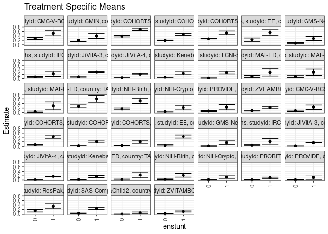

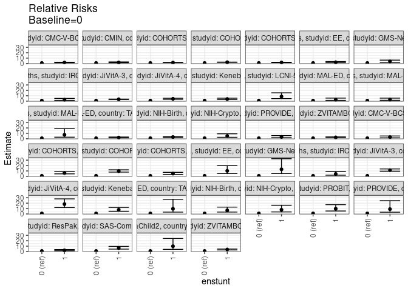

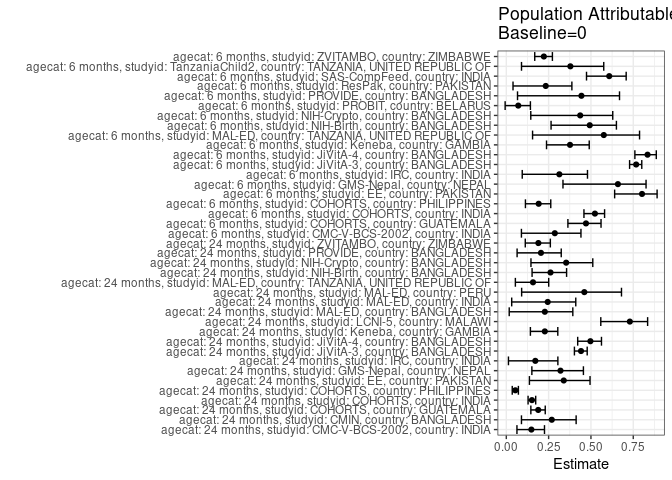

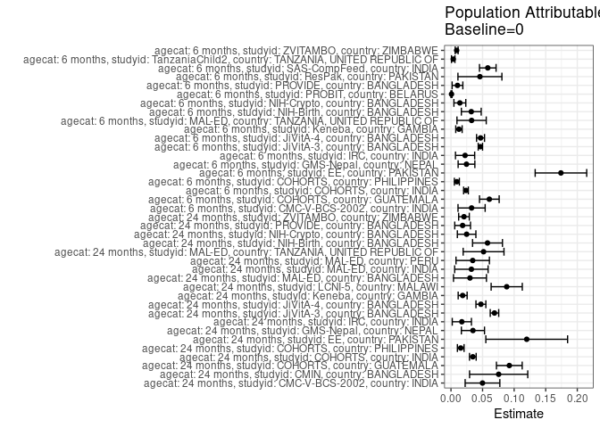

## Results Table

### Parameter: TSM

| agecat | studyid | country | intervention_level | baseline_level | estimate | ci_lower | ci_upper |
| --- | --- | --- | --- | --- | --- | --- | --- |
| 6 months | CMC-V-BCS-2002 | INDIA | 0 | NA | 0.0812118 | 0.0500197 | 0.1124038 |
| 6 months | CMC-V-BCS-2002 | INDIA | 1 | NA | 0.2385775 | 0.1412106 | 0.3359444 |
| 6 months | COHORTS | GUATEMALA | 0 | NA | 0.0682963 | 0.0509602 | 0.0856324 |
| 6 months | COHORTS | GUATEMALA | 1 | NA | 0.4317208 | 0.3536301 | 0.5098115 |
| 6 months | COHORTS | INDIA | 0 | NA | 0.0216029 | 0.0179510 | 0.0252549 |
| 6 months | COHORTS | INDIA | 1 | NA | 0.2100407 | 0.1819335 | 0.2381479 |
| 6 months | COHORTS | PHILIPPINES | 0 | NA | 0.0394226 | 0.0318691 | 0.0469760 |
| 6 months | COHORTS | PHILIPPINES | 1 | NA | 0.2011735 | 0.1360994 | 0.2662476 |
| 6 months | EE | PAKISTAN | 0 | NA | 0.0430622 | 0.0155042 | 0.0706202 |
| 6 months | EE | PAKISTAN | 1 | NA | 0.4390244 | 0.3629698 | 0.5150790 |
| 6 months | GMS-Nepal | NEPAL | 0 | NA | 0.0126850 | 0.0025907 | 0.0227793 |
| 6 months | GMS-Nepal | NEPAL | 1 | NA | 0.1648352 | 0.0885353 | 0.2411350 |
| 6 months | IRC | INDIA | 0 | NA | 0.0489251 | 0.0263255 | 0.0715247 |
| 6 months | IRC | INDIA | 1 | NA | 0.2150931 | 0.0942159 | 0.3359702 |
| 6 months | JiVitA-3 | BANGLADESH | 0 | NA | 0.0141339 | 0.0116860 | 0.0165819 |
| 6 months | JiVitA-3 | BANGLADESH | 1 | NA | 0.1614310 | 0.1510154 | 0.1718466 |
| 6 months | JiVitA-4 | BANGLADESH | 0 | NA | 0.0092887 | 0.0055286 | 0.0130488 |
| 6 months | JiVitA-4 | BANGLADESH | 1 | NA | 0.1693530 | 0.1482186 | 0.1904874 |
| 6 months | Keneba | GAMBIA | 0 | NA | 0.0208975 | 0.0144373 | 0.0273578 |
| 6 months | Keneba | GAMBIA | 1 | NA | 0.1621442 | 0.1090556 | 0.2152328 |
| 6 months | MAL-ED | TANZANIA, UNITED REPUBLIC OF | 0 | NA | 0.0240385 | 0.0031807 | 0.0448962 |
| 6 months | MAL-ED | TANZANIA, UNITED REPUBLIC OF | 1 | NA | 0.2307692 | 0.0982698 | 0.3632687 |
| 6 months | NIH-Birth | BANGLADESH | 0 | NA | 0.0330484 | 0.0164862 | 0.0496107 |
| 6 months | NIH-Birth | BANGLADESH | 1 | NA | 0.2192939 | 0.1295525 | 0.3090353 |
| 6 months | NIH-Crypto | BANGLADESH | 0 | NA | 0.0181266 | 0.0075952 | 0.0286580 |
| 6 months | NIH-Crypto | BANGLADESH | 1 | NA | 0.1403193 | 0.0781020 | 0.2025366 |
| 6 months | PROBIT | BELARUS | 0 | NA | 0.0104368 | 0.0046734 | 0.0162001 |
| 6 months | PROBIT | BELARUS | 1 | NA | 0.1015007 | 0.0747656 | 0.1282358 |
| 6 months | PROVIDE | BANGLADESH | 0 | NA | 0.0128913 | 0.0033954 | 0.0223873 |
| 6 months | PROVIDE | BANGLADESH | 1 | NA | 0.1147541 | 0.0347045 | 0.1948037 |
| 6 months | ResPak | PAKISTAN | 0 | NA | 0.1508395 | 0.0969698 | 0.2047093 |
| 6 months | ResPak | PAKISTAN | 1 | NA | 0.3452673 | 0.2367315 | 0.4538031 |
| 6 months | SAS-CompFeed | INDIA | 0 | NA | 0.0375491 | 0.0226667 | 0.0524315 |
| 6 months | SAS-CompFeed | INDIA | 1 | NA | 0.2475794 | 0.2111224 | 0.2840364 |
| 6 months | TanzaniaChild2 | TANZANIA, UNITED REPUBLIC OF | 0 | NA | 0.0058201 | 0.0023899 | 0.0092503 |
| 6 months | TanzaniaChild2 | TANZANIA, UNITED REPUBLIC OF | 1 | NA | 0.0575540 | 0.0188270 | 0.0962809 |
| 6 months | ZVITAMBO | ZIMBABWE | 0 | NA | 0.0315055 | 0.0276286 | 0.0353823 |
| 6 months | ZVITAMBO | ZIMBABWE | 1 | NA | 0.1191621 | 0.0972615 | 0.1410627 |
| 24 months | CMC-V-BCS-2002 | INDIA | 0 | NA | 0.2870342 | 0.2351457 | 0.3389227 |
| 24 months | CMC-V-BCS-2002 | INDIA | 1 | NA | 0.5239864 | 0.4107436 | 0.6372292 |
| 24 months | CMIN | BANGLADESH | 0 | NA | 0.2055031 | 0.1413391 | 0.2696671 |
| 24 months | CMIN | BANGLADESH | 1 | NA | 0.4040555 | 0.2995781 | 0.5085329 |
| 24 months | COHORTS | GUATEMALA | 0 | NA | 0.3973400 | 0.3621725 | 0.4325075 |
| 24 months | COHORTS | GUATEMALA | 1 | NA | 0.6980545 | 0.6486025 | 0.7475064 |
| 24 months | COHORTS | INDIA | 0 | NA | 0.1938223 | 0.1826044 | 0.2050403 |
| 24 months | COHORTS | INDIA | 1 | NA | 0.4717806 | 0.4345413 | 0.5090198 |
| 24 months | COHORTS | PHILIPPINES | 0 | NA | 0.2737219 | 0.2555920 | 0.2918518 |
| 24 months | COHORTS | PHILIPPINES | 1 | NA | 0.5434646 | 0.4601963 | 0.6267328 |
| 24 months | EE | PAKISTAN | 0 | NA | 0.2333781 | 0.1506084 | 0.3161477 |
| 24 months | EE | PAKISTAN | 1 | NA | 0.5572941 | 0.4365310 | 0.6780572 |
| 24 months | GMS-Nepal | NEPAL | 0 | NA | 0.0738427 | 0.0484133 | 0.0992721 |
| 24 months | GMS-Nepal | NEPAL | 1 | NA | 0.2838720 | 0.1820299 | 0.3857141 |
| 24 months | IRC | INDIA | 0 | NA | 0.0830614 | 0.0543559 | 0.1117669 |
| 24 months | IRC | INDIA | 1 | NA | 0.2245447 | 0.1072342 | 0.3418552 |
| 24 months | JiVitA-3 | BANGLADESH | 0 | NA | 0.0871746 | 0.0791499 | 0.0951993 |
| 24 months | JiVitA-3 | BANGLADESH | 1 | NA | 0.3013466 | 0.2826667 | 0.3200266 |
| 24 months | JiVitA-4 | BANGLADESH | 0 | NA | 0.0479651 | 0.0394023 | 0.0565278 |
| 24 months | JiVitA-4 | BANGLADESH | 1 | NA | 0.2066477 | 0.1821401 | 0.2311554 |
| 24 months | Keneba | GAMBIA | 0 | NA | 0.0626968 | 0.0506017 | 0.0747919 |
| 24 months | Keneba | GAMBIA | 1 | NA | 0.2465024 | 0.1814970 | 0.3115079 |
| 24 months | LCNI-5 | MALAWI | 0 | NA | 0.0326620 | 0.0147910 | 0.0505330 |
| 24 months | LCNI-5 | MALAWI | 1 | NA | 0.2789191 | 0.2163985 | 0.3414397 |
| 24 months | MAL-ED | BANGLADESH | 0 | NA | 0.1020189 | 0.0577871 | 0.1462508 |
| 24 months | MAL-ED | BANGLADESH | 1 | NA | 0.2879302 | 0.1264460 | 0.4494145 |
| 24 months | MAL-ED | INDIA | 0 | NA | 0.0998500 | 0.0572647 | 0.1424353 |
| 24 months | MAL-ED | INDIA | 1 | NA | 0.2929739 | 0.1500627 | 0.4358851 |
| 24 months | MAL-ED | PERU | 0 | NA | 0.0402299 | 0.0109604 | 0.0694993 |
| 24 months | MAL-ED | PERU | 1 | NA | 0.2962963 | 0.1236301 | 0.4689625 |
| 24 months | MAL-ED | TANZANIA, UNITED REPUBLIC OF | 0 | NA | 0.2755082 | 0.2098366 | 0.3411798 |
| 24 months | MAL-ED | TANZANIA, UNITED REPUBLIC OF | 1 | NA | 0.6112073 | 0.4557785 | 0.7666361 |
| 24 months | NIH-Birth | BANGLADESH | 0 | NA | 0.1636108 | 0.1249243 | 0.2022973 |
| 24 months | NIH-Birth | BANGLADESH | 1 | NA | 0.5146233 | 0.4006426 | 0.6286039 |
| 24 months | NIH-Crypto | BANGLADESH | 0 | NA | 0.0452774 | 0.0259839 | 0.0645710 |
| 24 months | NIH-Crypto | BANGLADESH | 1 | NA | 0.2224482 | 0.1212794 | 0.3236170 |
| 24 months | PROVIDE | BANGLADESH | 0 | NA | 0.0715453 | 0.0492782 | 0.0938125 |
| 24 months | PROVIDE | BANGLADESH | 1 | NA | 0.2374634 | 0.1235312 | 0.3513956 |
| 24 months | ZVITAMBO | ZIMBABWE | 0 | NA | 0.0879719 | 0.0731422 | 0.1028016 |
| 24 months | ZVITAMBO | ZIMBABWE | 1 | NA | 0.2235436 | 0.1694394 | 0.2776478 |

### Parameter: E(Y)

| agecat | studyid | country | intervention_level | baseline_level | estimate | ci_lower | ci_upper |
| --- | --- | --- | --- | --- | --- | --- | --- |
| 6 months | CMC-V-BCS-2002 | INDIA | NA | NA | 0.1138211 | 0.0813725 | 0.1462698 |
| 6 months | COHORTS | GUATEMALA | NA | NA | 0.1290323 | 0.1078261 | 0.1502384 |
| 6 months | COHORTS | INDIA | NA | NA | 0.0453353 | 0.0404119 | 0.0502586 |
| 6 months | COHORTS | PHILIPPINES | NA | NA | 0.0487445 | 0.0406327 | 0.0568562 |
| 6 months | EE | PAKISTAN | NA | NA | 0.2171582 | 0.1752594 | 0.2590570 |
| 6 months | GMS-Nepal | NEPAL | NA | NA | 0.0372340 | 0.0215945 | 0.0528736 |
| 6 months | IRC | INDIA | NA | NA | 0.0712531 | 0.0462303 | 0.0962759 |
| 6 months | JiVitA-3 | BANGLADESH | NA | NA | 0.0606746 | 0.0568229 | 0.0645262 |
| 6 months | JiVitA-4 | BANGLADESH | NA | NA | 0.0560960 | 0.0493335 | 0.0628586 |
| 6 months | Keneba | GAMBIA | NA | NA | 0.0335089 | 0.0257898 | 0.0412279 |
| 6 months | MAL-ED | TANZANIA, UNITED REPUBLIC OF | NA | NA | 0.0566802 | 0.0277850 | 0.0855754 |
| 6 months | NIH-Birth | BANGLADESH | NA | NA | 0.0651769 | 0.0442802 | 0.0860736 |
| 6 months | NIH-Crypto | BANGLADESH | NA | NA | 0.0321678 | 0.0192256 | 0.0451101 |
| 6 months | PROBIT | BELARUS | NA | NA | 0.0112310 | 0.0054733 | 0.0169886 |
| 6 months | PROVIDE | BANGLADESH | NA | NA | 0.0231788 | 0.0111688 | 0.0351888 |
| 6 months | ResPak | PAKISTAN | NA | NA | 0.1966527 | 0.1461562 | 0.2471492 |
| 6 months | SAS-CompFeed | INDIA | NA | NA | 0.0958084 | 0.0774939 | 0.1141229 |
| 6 months | TanzaniaChild2 | TANZANIA, UNITED REPUBLIC OF | NA | NA | 0.0093642 | 0.0051724 | 0.0135561 |
| 6 months | ZVITAMBO | ZIMBABWE | NA | NA | 0.0404891 | 0.0363397 | 0.0446385 |
| 24 months | CMC-V-BCS-2002 | INDIA | NA | NA | 0.3369272 | 0.2887662 | 0.3850883 |
| 24 months | CMIN | BANGLADESH | NA | NA | 0.2809917 | 0.2242434 | 0.3377401 |
| 24 months | COHORTS | GUATEMALA | NA | NA | 0.4897196 | 0.4597530 | 0.5196862 |
| 24 months | COHORTS | INDIA | NA | NA | 0.2284055 | 0.2171416 | 0.2396694 |
| 24 months | COHORTS | PHILIPPINES | NA | NA | 0.2891616 | 0.2711872 | 0.3071359 |
| 24 months | EE | PAKISTAN | NA | NA | 0.3532934 | 0.2805798 | 0.4260070 |
| 24 months | GMS-Nepal | NEPAL | NA | NA | 0.1086066 | 0.0809724 | 0.1362407 |
| 24 months | IRC | INDIA | NA | NA | 0.1002445 | 0.0711031 | 0.1293859 |
| 24 months | JiVitA-3 | BANGLADESH | NA | NA | 0.1560473 | 0.1472898 | 0.1648047 |
| 24 months | JiVitA-4 | BANGLADESH | NA | NA | 0.0953283 | 0.0857752 | 0.1048814 |
| 24 months | Keneba | GAMBIA | NA | NA | 0.0811594 | 0.0682689 | 0.0940499 |
| 24 months | LCNI-5 | MALAWI | NA | NA | 0.1208981 | 0.0943206 | 0.1474756 |
| 24 months | MAL-ED | BANGLADESH | NA | NA | 0.1320755 | 0.0863920 | 0.1777589 |
| 24 months | MAL-ED | INDIA | NA | NA | 0.1321586 | 0.0880054 | 0.1763117 |
| 24 months | MAL-ED | PERU | NA | NA | 0.0746269 | 0.0382069 | 0.1110468 |
| 24 months | MAL-ED | TANZANIA, UNITED REPUBLIC OF | NA | NA | 0.3271028 | 0.2640978 | 0.3901078 |
| 24 months | NIH-Birth | BANGLADESH | NA | NA | 0.2214452 | 0.1821080 | 0.2607825 |
| 24 months | NIH-Crypto | BANGLADESH | NA | NA | 0.0700389 | 0.0479542 | 0.0921236 |
| 24 months | PROVIDE | BANGLADESH | NA | NA | 0.0899654 | 0.0666186 | 0.1133122 |
| 24 months | ZVITAMBO | ZIMBABWE | NA | NA | 0.1085366 | 0.0934775 | 0.1235957 |

### Parameter: RR

| agecat | studyid | country | intervention_level | baseline_level | estimate | ci_lower | ci_upper |
| --- | --- | --- | --- | --- | --- | --- | --- |
| 6 months | CMC-V-BCS-2002 | INDIA | 0 | 0 | 1.000000 | 1.000000 | 1.000000 |
| 6 months | CMC-V-BCS-2002 | INDIA | 1 | 0 | 2.937721 | 1.681801 | 5.131525 |
| 6 months | COHORTS | GUATEMALA | 0 | 0 | 1.000000 | 1.000000 | 1.000000 |
| 6 months | COHORTS | GUATEMALA | 1 | 0 | 6.321288 | 4.627439 | 8.635163 |
| 6 months | COHORTS | INDIA | 0 | 0 | 1.000000 | 1.000000 | 1.000000 |
| 6 months | COHORTS | INDIA | 1 | 0 | 9.722796 | 7.840485 | 12.057003 |
| 6 months | COHORTS | PHILIPPINES | 0 | 0 | 1.000000 | 1.000000 | 1.000000 |
| 6 months | COHORTS | PHILIPPINES | 1 | 0 | 5.103004 | 3.505054 | 7.429458 |
| 6 months | EE | PAKISTAN | 0 | 0 | 1.000000 | 1.000000 | 1.000000 |
| 6 months | EE | PAKISTAN | 1 | 0 | 10.195122 | 5.253625 | 19.784531 |
| 6 months | GMS-Nepal | NEPAL | 0 | 0 | 1.000000 | 1.000000 | 1.000000 |
| 6 months | GMS-Nepal | NEPAL | 1 | 0 | 12.994506 | 5.175442 | 32.626618 |
| 6 months | IRC | INDIA | 0 | 0 | 1.000000 | 1.000000 | 1.000000 |
| 6 months | IRC | INDIA | 1 | 0 | 4.396373 | 2.142296 | 9.022141 |
| 6 months | JiVitA-3 | BANGLADESH | 0 | 0 | 1.000000 | 1.000000 | 1.000000 |
| 6 months | JiVitA-3 | BANGLADESH | 1 | 0 | 11.421529 | 9.529858 | 13.688695 |
| 6 months | JiVitA-4 | BANGLADESH | 0 | 0 | 1.000000 | 1.000000 | 1.000000 |
| 6 months | JiVitA-4 | BANGLADESH | 1 | 0 | 18.232173 | 11.912820 | 27.903733 |
| 6 months | Keneba | GAMBIA | 0 | 0 | 1.000000 | 1.000000 | 1.000000 |
| 6 months | Keneba | GAMBIA | 1 | 0 | 7.759016 | 4.946917 | 12.169666 |
| 6 months | MAL-ED | TANZANIA, UNITED REPUBLIC OF | 0 | 0 | 1.000000 | 1.000000 | 1.000000 |
| 6 months | MAL-ED | TANZANIA, UNITED REPUBLIC OF | 1 | 0 | 9.600000 | 3.391639 | 27.172703 |
| 6 months | NIH-Birth | BANGLADESH | 0 | 0 | 1.000000 | 1.000000 | 1.000000 |
| 6 months | NIH-Birth | BANGLADESH | 1 | 0 | 6.635529 | 3.483364 | 12.640147 |
| 6 months | NIH-Crypto | BANGLADESH | 0 | 0 | 1.000000 | 1.000000 | 1.000000 |
| 6 months | NIH-Crypto | BANGLADESH | 1 | 0 | 7.741075 | 3.727118 | 16.077904 |
| 6 months | PROBIT | BELARUS | 0 | 0 | 1.000000 | 1.000000 | 1.000000 |
| 6 months | PROBIT | BELARUS | 1 | 0 | 9.725300 | 5.488974 | 17.231173 |
| 6 months | PROVIDE | BANGLADESH | 0 | 0 | 1.000000 | 1.000000 | 1.000000 |
| 6 months | PROVIDE | BANGLADESH | 1 | 0 | 8.901639 | 3.227583 | 24.550630 |
| 6 months | ResPak | PAKISTAN | 0 | 0 | 1.000000 | 1.000000 | 1.000000 |
| 6 months | ResPak | PAKISTAN | 1 | 0 | 2.288971 | 1.432646 | 3.657139 |
| 6 months | SAS-CompFeed | INDIA | 0 | 0 | 1.000000 | 1.000000 | 1.000000 |
| 6 months | SAS-CompFeed | INDIA | 1 | 0 | 6.593479 | 4.554587 | 9.545096 |
| 6 months | TanzaniaChild2 | TANZANIA, UNITED REPUBLIC OF | 0 | 0 | 1.000000 | 1.000000 | 1.000000 |
| 6 months | TanzaniaChild2 | TANZANIA, UNITED REPUBLIC OF | 1 | 0 | 9.888816 | 4.042664 | 24.189171 |
| 6 months | ZVITAMBO | ZIMBABWE | 0 | 0 | 1.000000 | 1.000000 | 1.000000 |
| 6 months | ZVITAMBO | ZIMBABWE | 1 | 0 | 3.782266 | 3.031986 | 4.718206 |
| 24 months | CMC-V-BCS-2002 | INDIA | 0 | 0 | 1.000000 | 1.000000 | 1.000000 |
| 24 months | CMC-V-BCS-2002 | INDIA | 1 | 0 | 1.825519 | 1.376385 | 2.421212 |
| 24 months | CMIN | BANGLADESH | 0 | 0 | 1.000000 | 1.000000 | 1.000000 |
| 24 months | CMIN | BANGLADESH | 1 | 0 | 1.966177 | 1.312203 | 2.946079 |
| 24 months | COHORTS | GUATEMALA | 0 | 0 | 1.000000 | 1.000000 | 1.000000 |
| 24 months | COHORTS | GUATEMALA | 1 | 0 | 1.756819 | 1.569364 | 1.966664 |
| 24 months | COHORTS | INDIA | 0 | 0 | 1.000000 | 1.000000 | 1.000000 |
| 24 months | COHORTS | INDIA | 1 | 0 | 2.434088 | 2.210568 | 2.680208 |
| 24 months | COHORTS | PHILIPPINES | 0 | 0 | 1.000000 | 1.000000 | 1.000000 |
| 24 months | COHORTS | PHILIPPINES | 1 | 0 | 1.985462 | 1.681655 | 2.344156 |
| 24 months | EE | PAKISTAN | 0 | 0 | 1.000000 | 1.000000 | 1.000000 |
| 24 months | EE | PAKISTAN | 1 | 0 | 2.387946 | 1.569552 | 3.633064 |
| 24 months | GMS-Nepal | NEPAL | 0 | 0 | 1.000000 | 1.000000 | 1.000000 |
| 24 months | GMS-Nepal | NEPAL | 1 | 0 | 3.844279 | 2.336716 | 6.324468 |
| 24 months | IRC | INDIA | 0 | 0 | 1.000000 | 1.000000 | 1.000000 |
| 24 months | IRC | INDIA | 1 | 0 | 2.703356 | 1.446328 | 5.052889 |
| 24 months | JiVitA-3 | BANGLADESH | 0 | 0 | 1.000000 | 1.000000 | 1.000000 |
| 24 months | JiVitA-3 | BANGLADESH | 1 | 0 | 3.456818 | 3.105894 | 3.847391 |
| 24 months | JiVitA-4 | BANGLADESH | 0 | 0 | 1.000000 | 1.000000 | 1.000000 |
| 24 months | JiVitA-4 | BANGLADESH | 1 | 0 | 4.308297 | 3.470865 | 5.347780 |
| 24 months | Keneba | GAMBIA | 0 | 0 | 1.000000 | 1.000000 | 1.000000 |
| 24 months | Keneba | GAMBIA | 1 | 0 | 3.931658 | 2.835792 | 5.451013 |
| 24 months | LCNI-5 | MALAWI | 0 | 0 | 1.000000 | 1.000000 | 1.000000 |
| 24 months | LCNI-5 | MALAWI | 1 | 0 | 8.539559 | 4.732862 | 15.408029 |
| 24 months | MAL-ED | BANGLADESH | 0 | 0 | 1.000000 | 1.000000 | 1.000000 |
| 24 months | MAL-ED | BANGLADESH | 1 | 0 | 2.822322 | 1.405029 | 5.669280 |
| 24 months | MAL-ED | INDIA | 0 | 0 | 1.000000 | 1.000000 | 1.000000 |
| 24 months | MAL-ED | INDIA | 1 | 0 | 2.934139 | 1.539600 | 5.591824 |
| 24 months | MAL-ED | PERU | 0 | 0 | 1.000000 | 1.000000 | 1.000000 |
| 24 months | MAL-ED | PERU | 1 | 0 | 7.365079 | 2.899635 | 18.707319 |
| 24 months | MAL-ED | TANZANIA, UNITED REPUBLIC OF | 0 | 0 | 1.000000 | 1.000000 | 1.000000 |
| 24 months | MAL-ED | TANZANIA, UNITED REPUBLIC OF | 1 | 0 | 2.218472 | 1.565683 | 3.143431 |
| 24 months | NIH-Birth | BANGLADESH | 0 | 0 | 1.000000 | 1.000000 | 1.000000 |
| 24 months | NIH-Birth | BANGLADESH | 1 | 0 | 3.145412 | 2.279880 | 4.339533 |
| 24 months | NIH-Crypto | BANGLADESH | 0 | 0 | 1.000000 | 1.000000 | 1.000000 |
| 24 months | NIH-Crypto | BANGLADESH | 1 | 0 | 4.913005 | 2.635782 | 9.157666 |
| 24 months | PROVIDE | BANGLADESH | 0 | 0 | 1.000000 | 1.000000 | 1.000000 |
| 24 months | PROVIDE | BANGLADESH | 1 | 0 | 3.319061 | 1.873218 | 5.880878 |
| 24 months | ZVITAMBO | ZIMBABWE | 0 | 0 | 1.000000 | 1.000000 | 1.000000 |
| 24 months | ZVITAMBO | ZIMBABWE | 1 | 0 | 2.541080 | 1.892710 | 3.411557 |

### Parameter: PAR

| agecat | studyid | country | intervention_level | baseline_level | estimate | ci_lower | ci_upper |
| --- | --- | --- | --- | --- | --- | --- | --- |
| 6 months | CMC-V-BCS-2002 | INDIA | 0 | NA | 0.0326094 | 0.0111313 | 0.0540874 |
| 6 months | COHORTS | GUATEMALA | 0 | NA | 0.0607359 | 0.0451732 | 0.0762987 |
| 6 months | COHORTS | INDIA | 0 | NA | 0.0237324 | 0.0199941 | 0.0274707 |
| 6 months | COHORTS | PHILIPPINES | 0 | NA | 0.0093219 | 0.0053859 | 0.0132579 |
| 6 months | EE | PAKISTAN | 0 | NA | 0.1740960 | 0.1333052 | 0.2148868 |
| 6 months | GMS-Nepal | NEPAL | 0 | NA | 0.0245491 | 0.0112983 | 0.0377998 |
| 6 months | IRC | INDIA | 0 | NA | 0.0223280 | 0.0071353 | 0.0375206 |
| 6 months | JiVitA-3 | BANGLADESH | 0 | NA | 0.0465406 | 0.0430880 | 0.0499933 |
| 6 months | JiVitA-4 | BANGLADESH | 0 | NA | 0.0468074 | 0.0405249 | 0.0530898 |
| 6 months | Keneba | GAMBIA | 0 | NA | 0.0126113 | 0.0075615 | 0.0176612 |
| 6 months | MAL-ED | TANZANIA, UNITED REPUBLIC OF | 0 | NA | 0.0326417 | 0.0094626 | 0.0558208 |
| 6 months | NIH-Birth | BANGLADESH | 0 | NA | 0.0321285 | 0.0164215 | 0.0478354 |
| 6 months | NIH-Crypto | BANGLADESH | 0 | NA | 0.0140412 | 0.0046182 | 0.0234643 |
| 6 months | PROBIT | BELARUS | 0 | NA | 0.0007942 | 0.0000382 | 0.0015502 |
| 6 months | PROVIDE | BANGLADESH | 0 | NA | 0.0102875 | 0.0017857 | 0.0187892 |
| 6 months | ResPak | PAKISTAN | 0 | NA | 0.0458132 | 0.0110094 | 0.0806170 |
| 6 months | SAS-CompFeed | INDIA | 0 | NA | 0.0582593 | 0.0451218 | 0.0713967 |
| 6 months | TanzaniaChild2 | TANZANIA, UNITED REPUBLIC OF | 0 | NA | 0.0035441 | 0.0008206 | 0.0062676 |
| 6 months | ZVITAMBO | ZIMBABWE | 0 | NA | 0.0089836 | 0.0066896 | 0.0112776 |
| 24 months | CMC-V-BCS-2002 | INDIA | 0 | NA | 0.0498930 | 0.0224216 | 0.0773645 |
| 24 months | CMIN | BANGLADESH | 0 | NA | 0.0754886 | 0.0294124 | 0.1215649 |
| 24 months | COHORTS | GUATEMALA | 0 | NA | 0.0923796 | 0.0720066 | 0.1127527 |
| 24 months | COHORTS | INDIA | 0 | NA | 0.0345831 | 0.0293052 | 0.0398611 |
| 24 months | COHORTS | PHILIPPINES | 0 | NA | 0.0154396 | 0.0101640 | 0.0207152 |
| 24 months | EE | PAKISTAN | 0 | NA | 0.1199154 | 0.0551747 | 0.1846560 |
| 24 months | GMS-Nepal | NEPAL | 0 | NA | 0.0347638 | 0.0164423 | 0.0530853 |
| 24 months | IRC | INDIA | 0 | NA | 0.0171831 | 0.0019882 | 0.0323779 |
| 24 months | JiVitA-3 | BANGLADESH | 0 | NA | 0.0688727 | 0.0621682 | 0.0755772 |
| 24 months | JiVitA-4 | BANGLADESH | 0 | NA | 0.0473632 | 0.0395200 | 0.0552064 |
| 24 months | Keneba | GAMBIA | 0 | NA | 0.0184626 | 0.0113665 | 0.0255587 |
| 24 months | LCNI-5 | MALAWI | 0 | NA | 0.0882361 | 0.0635712 | 0.1129010 |
| 24 months | MAL-ED | BANGLADESH | 0 | NA | 0.0300566 | 0.0039782 | 0.0561349 |
| 24 months | MAL-ED | INDIA | 0 | NA | 0.0323086 | 0.0058368 | 0.0587803 |
| 24 months | MAL-ED | PERU | 0 | NA | 0.0343970 | 0.0079419 | 0.0608520 |
| 24 months | MAL-ED | TANZANIA, UNITED REPUBLIC OF | 0 | NA | 0.0515946 | 0.0192738 | 0.0839154 |
| 24 months | NIH-Birth | BANGLADESH | 0 | NA | 0.0578344 | 0.0341567 | 0.0815122 |
| 24 months | NIH-Crypto | BANGLADESH | 0 | NA | 0.0247615 | 0.0100838 | 0.0394392 |
| 24 months | PROVIDE | BANGLADESH | 0 | NA | 0.0184201 | 0.0059525 | 0.0308876 |
| 24 months | ZVITAMBO | ZIMBABWE | 0 | NA | 0.0205647 | 0.0121383 | 0.0289911 |

### Parameter: PAF

| agecat | studyid | country | intervention_level | baseline_level | estimate | ci_lower | ci_upper |
| --- | --- | --- | --- | --- | --- | --- | --- |
| 6 months | CMC-V-BCS-2002 | INDIA | 0 | NA | 0.2864968 | 0.0893254 | 0.4409783 |
| 6 months | COHORTS | GUATEMALA | 0 | NA | 0.4707035 | 0.3638873 | 0.5595830 |
| 6 months | COHORTS | INDIA | 0 | NA | 0.5234855 | 0.4586517 | 0.5805546 |
| 6 months | COHORTS | PHILIPPINES | 0 | NA | 0.1912401 | 0.1129654 | 0.2626077 |
| 6 months | EE | PAKISTAN | 0 | NA | 0.8017012 | 0.6399535 | 0.8907852 |
| 6 months | GMS-Nepal | NEPAL | 0 | NA | 0.6593174 | 0.3347627 | 0.8255290 |
| 6 months | IRC | INDIA | 0 | NA | 0.3133613 | 0.0941084 | 0.4795484 |
| 6 months | JiVitA-3 | BANGLADESH | 0 | NA | 0.7670535 | 0.7283362 | 0.8002529 |
| 6 months | JiVitA-4 | BANGLADESH | 0 | NA | 0.8344146 | 0.7595181 | 0.8859850 |
| 6 months | Keneba | GAMBIA | 0 | NA | 0.3763581 | 0.2375964 | 0.4898644 |
| 6 months | MAL-ED | TANZANIA, UNITED REPUBLIC OF | 0 | NA | 0.5758929 | 0.1551277 | 0.7871076 |
| 6 months | NIH-Birth | BANGLADESH | 0 | NA | 0.4929424 | 0.2644242 | 0.6504678 |
| 6 months | NIH-Crypto | BANGLADESH | 0 | NA | 0.4364995 | 0.1445926 | 0.6287935 |
| 6 months | PROBIT | BELARUS | 0 | NA | 0.0707149 | -0.0069342 | 0.1423761 |
| 6 months | PROVIDE | BANGLADESH | 0 | NA | 0.4438306 | 0.0662412 | 0.6687320 |
| 6 months | ResPak | PAKISTAN | 0 | NA | 0.2329649 | 0.0396431 | 0.3873706 |
| 6 months | SAS-CompFeed | INDIA | 0 | NA | 0.6080809 | 0.4738016 | 0.7080938 |
| 6 months | TanzaniaChild2 | TANZANIA, UNITED REPUBLIC OF | 0 | NA | 0.3784740 | 0.0897894 | 0.5755986 |
| 6 months | ZVITAMBO | ZIMBABWE | 0 | NA | 0.2218775 | 0.1679489 | 0.2723109 |
| 24 months | CMC-V-BCS-2002 | INDIA | 0 | NA | 0.1480825 | 0.0628554 | 0.2255588 |
| 24 months | CMIN | BANGLADESH | 0 | NA | 0.2686507 | 0.0895685 | 0.4125074 |
| 24 months | COHORTS | GUATEMALA | 0 | NA | 0.1886378 | 0.1450341 | 0.2300176 |
| 24 months | COHORTS | INDIA | 0 | NA | 0.1514111 | 0.1286186 | 0.1736074 |
| 24 months | COHORTS | PHILIPPINES | 0 | NA | 0.0533945 | 0.0350618 | 0.0713788 |
| 24 months | EE | PAKISTAN | 0 | NA | 0.3394214 | 0.1364942 | 0.4946600 |
| 24 months | GMS-Nepal | NEPAL | 0 | NA | 0.3200897 | 0.1509818 | 0.4555145 |
| 24 months | IRC | INDIA | 0 | NA | 0.1714116 | 0.0126821 | 0.3046223 |
| 24 months | JiVitA-3 | BANGLADESH | 0 | NA | 0.4413578 | 0.4023488 | 0.4778207 |
| 24 months | JiVitA-4 | BANGLADESH | 0 | NA | 0.4968433 | 0.4217060 | 0.5622181 |
| 24 months | Keneba | GAMBIA | 0 | NA | 0.2274857 | 0.1423354 | 0.3041822 |
| 24 months | LCNI-5 | MALAWI | 0 | NA | 0.7298386 | 0.5581565 | 0.8348121 |
| 24 months | MAL-ED | BANGLADESH | 0 | NA | 0.2275710 | 0.0172262 | 0.3928954 |
| 24 months | MAL-ED | INDIA | 0 | NA | 0.2444680 | 0.0319121 | 0.4103546 |
| 24 months | MAL-ED | PERU | 0 | NA | 0.4609195 | 0.0905879 | 0.6804444 |
| 24 months | MAL-ED | TANZANIA, UNITED REPUBLIC OF | 0 | NA | 0.1577320 | 0.0535272 | 0.2504641 |
| 24 months | NIH-Birth | BANGLADESH | 0 | NA | 0.2611681 | 0.1522159 | 0.3561185 |
| 24 months | NIH-Crypto | BANGLADESH | 0 | NA | 0.3535390 | 0.1456356 | 0.5108505 |
| 24 months | PROVIDE | BANGLADESH | 0 | NA | 0.2047460 | 0.0637427 | 0.3245137 |
| 24 months | ZVITAMBO | ZIMBABWE | 0 | NA | 0.1894727 | 0.1120621 | 0.2601346 |